# Correlation and Linear Regression

Jeremy Mathews

January 17, 2020

## Pearson Correlation

The Pearson correlation coefficient (r) is a measure of the linear correlation between two variables. In otherwords to tells how strong or weak the linear relationship between two variables is.

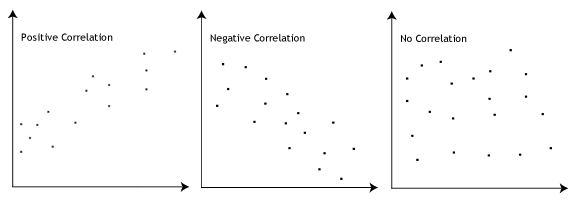

- $-1 \le r \le 1$
  - r = 0: No linear association between the two variables. **CAREFUL! This does not imply independence.**
  - r = 1: There is a perfect positive linear association between the two variables.
  - r = -1: There is a perfect negative linear association between the two variables.
- Assumption: Both sample variables are drawn from normal distributions.
  - Test for Normality
  - Can be approximate for non-normal distributions but requires a large sample size.
- Hypothesis:
  - H0: $\rho$ = 0
  - H1: $\rho \ne$ 0

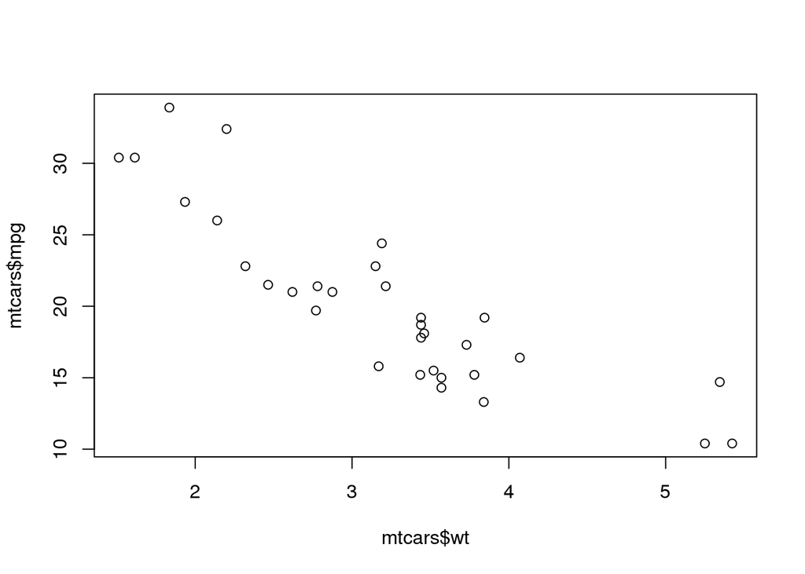

```r
data("mtcars")
plot(mtcars$wt, mtcars$mpg)
```

```r
cor.test(mtcars$wt, mtcars$mpg)
```

```
##
##  Pearson's product-moment correlation
##
## data:  mtcars$wt and mtcars$mpg
## t = -9.559, df = 30, p-value = 1.294e-10
## alternative hypothesis: true correlation is not equal to 0
## 95 percent confidence interval:
##  -0.9338264 -0.7440872
## sample estimates:
##        cor
## -0.8676594
```

```r
cor.test(mtcars$wt, mtcars$mpg, "less")
```

```
##
##  Pearson's product-moment correlation
##
## data:  mtcars$wt and mtcars$mpg
## t = -9.559, df = 30, p-value = 6.47e-11
## alternative hypothesis: true correlation is less than 0
## 95 percent confidence interval:
##  -1.0000000 -0.7690872
## sample estimates:
##        cor
## -0.8676594
```

The Pearson correlation test also returns a p-value that can be compared to a predetermined alpha value. Based on the results, there is enough statistical significance to conclude that the weight and mpg of a car have a relatively strong negative correlation.

What if the data is not linear? **Spearman Rank Correlation**

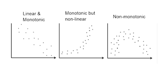

#### *Correlation $\ne$ Causation*

## Linear Regression

Linear Regression is a method of modeling the relationship between two variables. Typically, this is when one variable is independent and the other is a response variable. Linear Regression is one of the most basic methods of relationship modeling because it attempts to describe the population relationship using a strait line.
$$Y = \beta_1x + \beta_0 + \epsilon$$
In this equation, $\beta_1$ is the slope of the line, $\beta_0$ is the y-intercept, and $\epsilon$ is the error. $\epsilon$ is not always listed or shown.

- Assumption: **LINE**
  - Linear relationship
  - Independent errors
  - Normally distributed errors
  - Equal residual variance (Homoscedasticity)
- Hypothesis:
  - H0: $\beta_0$ and $\beta_1$ are 0
  - H1: $\beta_0$ or $\beta_1$ are not 0

```r
data("cars")
scatter.smooth(x=cars$speed, y=cars$dist, main="Dist ~ Speed")
lr <- lm(dist ~ speed, data=cars)
lr
```

```
##
## Call:
## lm(formula = dist ~ speed, data = cars)
##
## Coefficients:
## (Intercept)        speed
##     -17.579        3.932
```

```r
summary(lr)
```

```
##
## Call:
## lm(formula = dist ~ speed, data = cars)
##
## Residuals:
##     Min      1Q  Median      3Q     Max
## -29.069  -9.525  -2.272   9.215  43.201
##
## Coefficients:
##             Estimate Std. Error t value Pr(>|t|)
## (Intercept) -17.5791     6.7584  -2.601   0.0123 *
## speed         3.9324     0.4155   9.464 1.49e-12 ***
## ---
## Signif. codes:  0 '***' 0.001 '**' 0.01 '*' 0.05 '.' 0.1 ' ' 1
##
## Residual standard error: 15.38 on 48 degrees of freedom
## Multiple R-squared:  0.6511, Adjusted R-squared:  0.6438
## F-statistic: 89.57 on 1 and 48 DF,  p-value: 1.49e-12
```

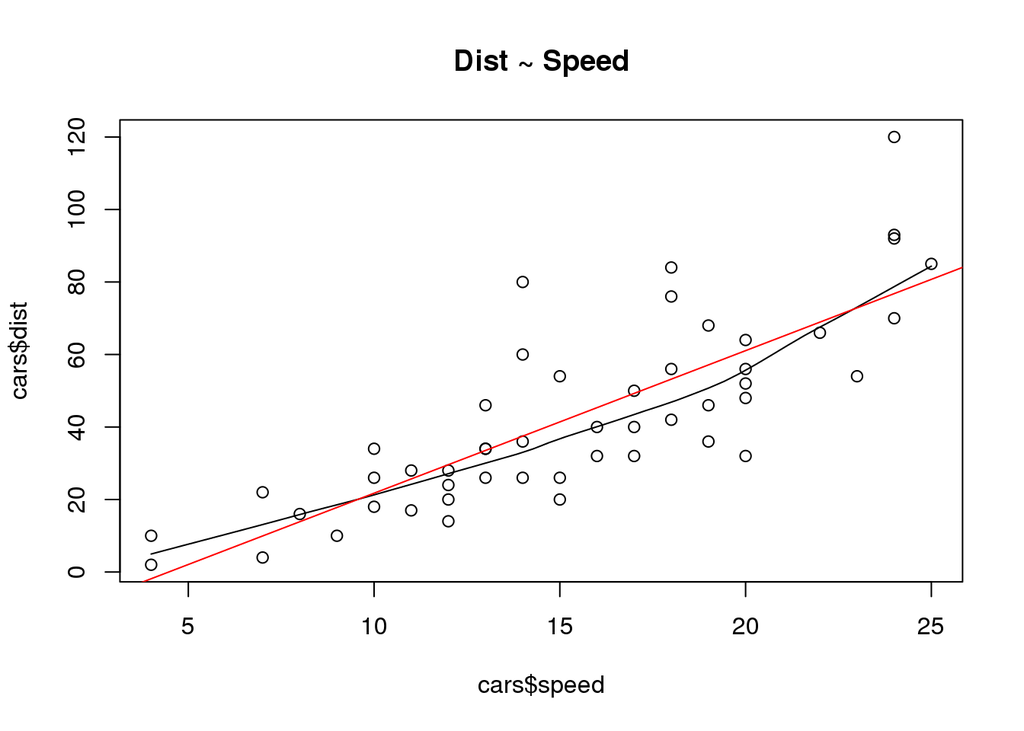

```r
abline(lr, col="red")
```

So how do we interpret these results? Like other tests, there is a p-value outputted which helps us either reject or fail to reject the null hypothesis. the lm() function also outputs the estimated values for $\beta_0$ and $\beta_1$ from this model. Finally, there is an R-squared value that is of importance to us. This is the residual-squared value which describes the amount of variation explained by this linear regression model. R-squared is a value between 0 and 1, 0 being no variance is explained and 1 being all the variance is explained.